# Risk Factor Analysis

## Outcome Variable

**Outcome Variable:** ever_stunted

## Predictor Variables

**Intervention Variable:** parity

**Adjustment Set:**

unadjusted

## Stratifying Variables

The analysis was stratified on these variable(s):

- agecat
- studyid
- country

## Data Summary

| agecat | studyid | country | parity | ever_stunted | n_cell | n |
| --- | --- | --- | --- | --- | --- | --- |
| 0-24 months | COHORTS | GUATEMALA | 1 | 0 | 54 | 1360 |
| 0-24 months | COHORTS | GUATEMALA | 1 | 1 | 159 | 1360 |
| 0-24 months | COHORTS | GUATEMALA | 2 | 0 | 44 | 1360 |
| 0-24 months | COHORTS | GUATEMALA | 2 | 1 | 148 | 1360 |
| 0-24 months | COHORTS | GUATEMALA | 3+ | 0 | 223 | 1360 |
| 0-24 months | COHORTS | GUATEMALA | 3+ | 1 | 732 | 1360 |
| 0-24 months | COHORTS | INDIA | 1 | 0 | 511 | 4630 |
| 0-24 months | COHORTS | INDIA | 1 | 1 | 301 | 4630 |
| 0-24 months | COHORTS | INDIA | 2 | 0 | 797 | 4630 |
| 0-24 months | COHORTS | INDIA | 2 | 1 | 388 | 4630 |
| 0-24 months | COHORTS | INDIA | 3+ | 0 | 1511 | 4630 |
| 0-24 months | COHORTS | INDIA | 3+ | 1 | 1122 | 4630 |
| 0-24 months | COHORTS | PHILIPPINES | 1 | 0 | 269 | 3058 |
| 0-24 months | COHORTS | PHILIPPINES | 1 | 1 | 409 | 3058 |
| 0-24 months | COHORTS | PHILIPPINES | 2 | 0 | 242 | 3058 |
| 0-24 months | COHORTS | PHILIPPINES | 2 | 1 | 448 | 3058 |
| 0-24 months | COHORTS | PHILIPPINES | 3+ | 0 | 448 | 3058 |
| 0-24 months | COHORTS | PHILIPPINES | 3+ | 1 | 1242 | 3058 |
| 0-24 months | GMS-Nepal | NEPAL | 1 | 0 | 74 | 698 |
| 0-24 months | GMS-Nepal | NEPAL | 1 | 1 | 137 | 698 |
| 0-24 months | GMS-Nepal | NEPAL | 2 | 0 | 74 | 698 |
| 0-24 months | GMS-Nepal | NEPAL | 2 | 1 | 107 | 698 |
| 0-24 months | GMS-Nepal | NEPAL | 3+ | 0 | 104 | 698 |
| 0-24 months | GMS-Nepal | NEPAL | 3+ | 1 | 202 | 698 |
| 0-24 months | JiVitA-3 | BANGLADESH | 1 | 0 | 4760 | 27227 |
| 0-24 months | JiVitA-3 | BANGLADESH | 1 | 1 | 5492 | 27227 |
| 0-24 months | JiVitA-3 | BANGLADESH | 2 | 0 | 4853 | 27227 |
| 0-24 months | JiVitA-3 | BANGLADESH | 2 | 1 | 4146 | 27227 |
| 0-24 months | JiVitA-3 | BANGLADESH | 3+ | 0 | 4128 | 27227 |
| 0-24 months | JiVitA-3 | BANGLADESH | 3+ | 1 | 3848 | 27227 |

[output cut: 168 more lines]

The following strata were considered:

- agecat: 0-24 months, studyid: COHORTS, country: GUATEMALA
- agecat: 0-24 months, studyid: COHORTS, country: INDIA
- agecat: 0-24 months, studyid: COHORTS, country: PHILIPPINES
- agecat: 0-24 months, studyid: GMS-Nepal, country: NEPAL
- agecat: 0-24 months, studyid: JiVitA-3, country: BANGLADESH
- agecat: 0-24 months, studyid: Keneba, country: GAMBIA
- agecat: 0-24 months, studyid: PROVIDE, country: BANGLADESH
- agecat: 0-24 months, studyid: SAS-CompFeed, country: INDIA
- agecat: 0-24 months, studyid: SAS-FoodSuppl, country: INDIA
- agecat: 0-24 months, studyid: TanzaniaChild2, country: TANZANIA, UNITED REPUBLIC OF
- agecat: 0-24 months, studyid: ZVITAMBO, country: ZIMBABWE
- agecat: 0-6 months, studyid: COHORTS, country: GUATEMALA
- agecat: 0-6 months, studyid: COHORTS, country: INDIA
- agecat: 0-6 months, studyid: COHORTS, country: PHILIPPINES
- agecat: 0-6 months, studyid: GMS-Nepal, country: NEPAL
- agecat: 0-6 months, studyid: JiVitA-3, country: BANGLADESH
- agecat: 0-6 months, studyid: Keneba, country: GAMBIA
- agecat: 0-6 months, studyid: PROVIDE, country: BANGLADESH
- agecat: 0-6 months, studyid: SAS-CompFeed, country: INDIA
- agecat: 0-6 months, studyid: SAS-FoodSuppl, country: INDIA
- agecat: 0-6 months, studyid: TanzaniaChild2, country: TANZANIA, UNITED REPUBLIC OF
- agecat: 0-6 months, studyid: ZVITAMBO, country: ZIMBABWE
- agecat: 6-24 months, studyid: COHORTS, country: GUATEMALA
- agecat: 6-24 months, studyid: COHORTS, country: INDIA
- agecat: 6-24 months, studyid: COHORTS, country: PHILIPPINES
- agecat: 6-24 months, studyid: GMS-Nepal, country: NEPAL
- agecat: 6-24 months, studyid: JiVitA-3, country: BANGLADESH
- agecat: 6-24 months, studyid: Keneba, country: GAMBIA
- agecat: 6-24 months, studyid: PROVIDE, country: BANGLADESH
- agecat: 6-24 months, studyid: SAS-CompFeed, country: INDIA
- agecat: 6-24 months, studyid: SAS-FoodSuppl, country: INDIA
- agecat: 6-24 months, studyid: TanzaniaChild2, country: TANZANIA, UNITED REPUBLIC OF
- agecat: 6-24 months, studyid: ZVITAMBO, country: ZIMBABWE

### Dropped Strata

Some strata were dropped due to rare outcomes:

- agecat: 6-24 months, studyid: SAS-FoodSuppl, country: INDIA

## Methods Detail

We’re interested in the causal parameters $E[Y_a]$ for all values of $a \in \mathcal{A}$. These parameters represent the mean outcome if, possibly contrary to fact, we intervened to set all units to have $A=a$. Under the randomization and positivity assumptions, these are identified by the statistical parameters $\psi_a=E_W[E_{Y|A,W}(Y|A=a,W)]$. In addition, we’re interested in the mean of $Y$, $E[Y]$ under no intervention (the observed mean). We will estimate these parameters by using SuperLearner to fit the relevant likelihood factors – $E_{Y|A,W}(Y|A=a,W)$ and $p(A=a|W)$, and then updating our likelihood fit using a joint TMLE.

For unadjusted analyses ($W=\{\}$), initial likelihoods were estimated using Lrnr_glm to estimate the simple $E(Y|A)$ and Lrnr_mean to estimate $p(A)$. For adjusted analyses, a small library containing Lrnr_glmnet, Lrnr_xgboost, and Lrnr_mean was used.

Having estimated these parameters, we will then use the delta method to estimate relative risks and attributable risks relative to a prespecified baseline level of $A$.

# Results Detail

## Results Plots

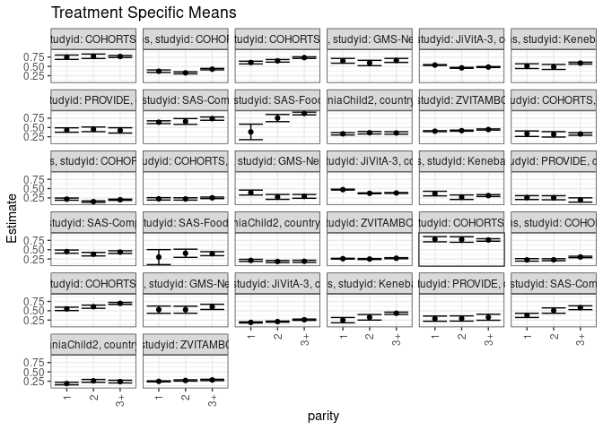

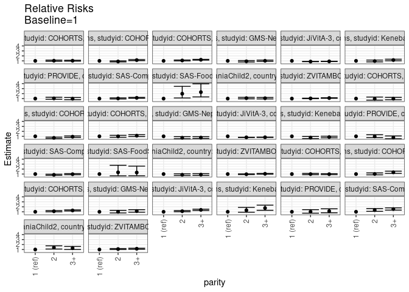

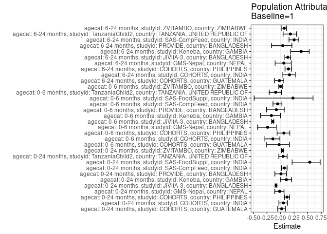

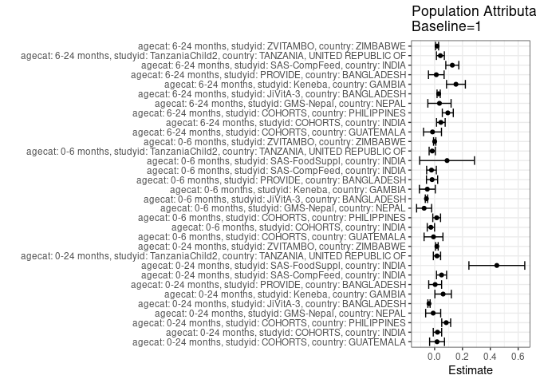

## Results Table

### Parameter: TSM

| agecat | studyid | country | intervention_level | baseline_level | estimate | ci_lower | ci_upper |
| --- | --- | --- | --- | --- | --- | --- | --- |
| 0-24 months | COHORTS | GUATEMALA | 1 | NA | 0.7464789 | 0.6880357 | 0.8049221 |
| 0-24 months | COHORTS | GUATEMALA | 2 | NA | 0.7708333 | 0.7113612 | 0.8303054 |
| 0-24 months | COHORTS | GUATEMALA | 3+ | NA | 0.7664921 | 0.7396504 | 0.7933339 |
| 0-24 months | COHORTS | INDIA | 1 | NA | 0.3706897 | 0.3374654 | 0.4039139 |
| 0-24 months | COHORTS | INDIA | 2 | NA | 0.3274262 | 0.3007046 | 0.3541478 |
| 0-24 months | COHORTS | INDIA | 3+ | NA | 0.4261299 | 0.4072392 | 0.4450206 |
| 0-24 months | COHORTS | PHILIPPINES | 1 | NA | 0.6032448 | 0.5664139 | 0.6400757 |
| 0-24 months | COHORTS | PHILIPPINES | 2 | NA | 0.6492754 | 0.6136637 | 0.6848870 |
| 0-24 months | COHORTS | PHILIPPINES | 3+ | NA | 0.7349112 | 0.7138643 | 0.7559582 |
| 0-24 months | GMS-Nepal | NEPAL | 1 | NA | 0.6492891 | 0.5848556 | 0.7137226 |
| 0-24 months | GMS-Nepal | NEPAL | 2 | NA | 0.5911602 | 0.5194883 | 0.6628322 |
| 0-24 months | GMS-Nepal | NEPAL | 3+ | NA | 0.6601307 | 0.6070215 | 0.7132399 |
| 0-24 months | JiVitA-3 | BANGLADESH | 1 | NA | 0.5357004 | 0.5240682 | 0.5473325 |
| 0-24 months | JiVitA-3 | BANGLADESH | 2 | NA | 0.4607179 | 0.4492037 | 0.4722321 |
| 0-24 months | JiVitA-3 | BANGLADESH | 3+ | NA | 0.4824473 | 0.4699742 | 0.4949205 |
| 0-24 months | Keneba | GAMBIA | 1 | NA | 0.5062241 | 0.4430869 | 0.5693612 |
| 0-24 months | Keneba | GAMBIA | 2 | NA | 0.4859813 | 0.4190006 | 0.5529620 |
| 0-24 months | Keneba | GAMBIA | 3+ | NA | 0.5882736 | 0.5636474 | 0.6128998 |
| 0-24 months | PROVIDE | BANGLADESH | 1 | NA | 0.4317343 | 0.3727199 | 0.4907487 |
| 0-24 months | PROVIDE | BANGLADESH | 2 | NA | 0.4508197 | 0.3883423 | 0.5132970 |
| 0-24 months | PROVIDE | BANGLADESH | 3+ | NA | 0.4216216 | 0.3504118 | 0.4928315 |
| 0-24 months | SAS-CompFeed | INDIA | 1 | NA | 0.6415929 | 0.6043150 | 0.6788709 |
| 0-24 months | SAS-CompFeed | INDIA | 2 | NA | 0.6611111 | 0.5839267 | 0.7382956 |
| 0-24 months | SAS-CompFeed | INDIA | 3+ | NA | 0.7378641 | 0.6940814 | 0.7816467 |
| 0-24 months | SAS-FoodSuppl | INDIA | 1 | NA | 0.3809524 | 0.1730038 | 0.5889009 |
| 0-24 months | SAS-FoodSuppl | INDIA | 2 | NA | 0.7532468 | 0.6568366 | 0.8496569 |
| 0-24 months | SAS-FoodSuppl | INDIA | 3+ | NA | 0.8750000 | 0.8387213 | 0.9112787 |
| 0-24 months | TanzaniaChild2 | TANZANIA, UNITED REPUBLIC OF | 1 | NA | 0.3300853 | 0.2979123 | 0.3622583 |
| 0-24 months | TanzaniaChild2 | TANZANIA, UNITED REPUBLIC OF | 2 | NA | 0.3592737 | 0.3254000 | 0.3931473 |
| 0-24 months | TanzaniaChild2 | TANZANIA, UNITED REPUBLIC OF | 3+ | NA | 0.3529412 | 0.3190698 | 0.3868125 |

[output cut: 66 more lines]

### Parameter: E(Y)

| agecat | studyid | country | intervention_level | baseline_level | estimate | ci_lower | ci_upper |
| --- | --- | --- | --- | --- | --- | --- | --- |
| 0-24 months | COHORTS | GUATEMALA | NA | NA | 0.7639706 | 0.7413939 | 0.7865473 |
| 0-24 months | COHORTS | INDIA | NA | NA | 0.3911447 | 0.3770865 | 0.4052029 |
| 0-24 months | COHORTS | PHILIPPINES | NA | NA | 0.6863963 | 0.6699497 | 0.7028430 |
| 0-24 months | GMS-Nepal | NEPAL | NA | NA | 0.6389685 | 0.6033115 | 0.6746254 |
| 0-24 months | JiVitA-3 | BANGLADESH | NA | NA | 0.4953171 | 0.4874955 | 0.5031388 |
| 0-24 months | Keneba | GAMBIA | NA | NA | 0.5673367 | 0.5455633 | 0.5891101 |
| 0-24 months | PROVIDE | BANGLADESH | NA | NA | 0.4357143 | 0.3989556 | 0.4724730 |
| 0-24 months | SAS-CompFeed | INDIA | NA | NA | 0.6914547 | 0.6510509 | 0.7318584 |
| 0-24 months | SAS-FoodSuppl | INDIA | NA | NA | 0.8277512 | 0.7915095 | 0.8639929 |
| 0-24 months | TanzaniaChild2 | TANZANIA, UNITED REPUBLIC OF | NA | NA | 0.3470513 | 0.3278294 | 0.3662733 |
| 0-24 months | ZVITAMBO | ZIMBABWE | NA | NA | 0.4171108 | 0.4089639 | 0.4252576 |
| 0-6 months | COHORTS | GUATEMALA | NA | NA | 0.3253896 | 0.2975756 | 0.3532035 |
| 0-6 months | COHORTS | INDIA | NA | NA | 0.1902526 | 0.1787489 | 0.2017563 |
| 0-6 months | COHORTS | PHILIPPINES | NA | NA | 0.2390451 | 0.2239262 | 0.2541640 |
| 0-6 months | GMS-Nepal | NEPAL | NA | NA | 0.3180516 | 0.2834770 | 0.3526261 |
| 0-6 months | JiVitA-3 | BANGLADESH | NA | NA | 0.4129818 | 0.4055453 | 0.4204184 |
| 0-6 months | Keneba | GAMBIA | NA | NA | 0.3135456 | 0.2924164 | 0.3346748 |
| 0-6 months | PROVIDE | BANGLADESH | NA | NA | 0.2400000 | 0.2083392 | 0.2716608 |
| 0-6 months | SAS-CompFeed | INDIA | NA | NA | 0.4254902 | 0.3977202 | 0.4532601 |
| 0-6 months | SAS-FoodSuppl | INDIA | NA | NA | 0.3894231 | 0.3425088 | 0.4363374 |
| 0-6 months | TanzaniaChild2 | TANZANIA, UNITED REPUBLIC OF | NA | NA | 0.1947391 | 0.1787488 | 0.2107293 |
| 0-6 months | ZVITAMBO | ZIMBABWE | NA | NA | 0.2586796 | 0.2514399 | 0.2659192 |
| 6-24 months | COHORTS | GUATEMALA | NA | NA | 0.7642458 | 0.7364214 | 0.7920702 |
| 6-24 months | COHORTS | INDIA | NA | NA | 0.2705750 | 0.2559548 | 0.2851951 |
| 6-24 months | COHORTS | PHILIPPINES | NA | NA | 0.6449788 | 0.6246093 | 0.6653483 |
| 6-24 months | GMS-Nepal | NEPAL | NA | NA | 0.5642317 | 0.5153938 | 0.6130696 |
| 6-24 months | JiVitA-3 | BANGLADESH | NA | NA | 0.2162394 | 0.2068628 | 0.2256160 |
| 6-24 months | Keneba | GAMBIA | NA | NA | 0.4014652 | 0.3754511 | 0.4274793 |
| 6-24 months | PROVIDE | BANGLADESH | NA | NA | 0.3004386 | 0.2583143 | 0.3425629 |
| 6-24 months | SAS-CompFeed | INDIA | NA | NA | 0.5030750 | 0.4588491 | 0.5473009 |
| 6-24 months | TanzaniaChild2 | TANZANIA, UNITED REPUBLIC OF | NA | NA | 0.2276474 | 0.2069456 | 0.2483493 |
| 6-24 months | ZVITAMBO | ZIMBABWE | NA | NA | 0.2629473 | 0.2535857 | 0.2723089 |

### Parameter: RR

| agecat | studyid | country | intervention_level | baseline_level | estimate | ci_lower | ci_upper |
| --- | --- | --- | --- | --- | --- | --- | --- |
| 0-24 months | COHORTS | GUATEMALA | 1 | 1 | 1.0000000 | 1.0000000 | 1.0000000 |
| 0-24 months | COHORTS | GUATEMALA | 2 | 1 | 1.0326258 | 0.9251364 | 1.1526042 |
| 0-24 months | COHORTS | GUATEMALA | 3+ | 1 | 1.0268102 | 0.9424149 | 1.1187633 |
| 0-24 months | COHORTS | INDIA | 1 | 1 | 1.0000000 | 1.0000000 | 1.0000000 |
| 0-24 months | COHORTS | INDIA | 2 | 1 | 0.8832892 | 0.7824544 | 0.9971185 |
| 0-24 months | COHORTS | INDIA | 3+ | 1 | 1.1495597 | 1.0401729 | 1.2704499 |
| 0-24 months | COHORTS | PHILIPPINES | 1 | 1 | 1.0000000 | 1.0000000 | 1.0000000 |
| 0-24 months | COHORTS | PHILIPPINES | 2 | 1 | 1.0763049 | 0.9914969 | 1.1683669 |
| 0-24 months | COHORTS | PHILIPPINES | 3+ | 1 | 1.2182636 | 1.1388157 | 1.3032541 |
| 0-24 months | GMS-Nepal | NEPAL | 1 | 1 | 1.0000000 | 1.0000000 | 1.0000000 |
| 0-24 months | GMS-Nepal | NEPAL | 2 | 1 | 0.9104730 | 0.7784381 | 1.0649031 |
| 0-24 months | GMS-Nepal | NEPAL | 3+ | 1 | 1.0166977 | 0.8947667 | 1.1552444 |
| 0-24 months | JiVitA-3 | BANGLADESH | 1 | 1 | 1.0000000 | 1.0000000 | 1.0000000 |
| 0-24 months | JiVitA-3 | BANGLADESH | 2 | 1 | 0.8600290 | 0.8347172 | 0.8861084 |
| 0-24 months | JiVitA-3 | BANGLADESH | 3+ | 1 | 0.9005918 | 0.8730176 | 0.9290369 |
| 0-24 months | Keneba | GAMBIA | 1 | 1 | 1.0000000 | 1.0000000 | 1.0000000 |
| 0-24 months | Keneba | GAMBIA | 2 | 1 | 0.9600123 | 0.7971684 | 1.1561216 |
| 0-24 months | Keneba | GAMBIA | 3+ | 1 | 1.1620815 | 1.0188282 | 1.3254770 |
| 0-24 months | PROVIDE | BANGLADESH | 1 | 1 | 1.0000000 | 1.0000000 | 1.0000000 |
| 0-24 months | PROVIDE | BANGLADESH | 2 | 1 | 1.0442062 | 0.8595054 | 1.2685979 |
| 0-24 months | PROVIDE | BANGLADESH | 3+ | 1 | 0.9765766 | 0.7858565 | 1.2135826 |
| 0-24 months | SAS-CompFeed | INDIA | 1 | 1 | 1.0000000 | 1.0000000 | 1.0000000 |
| 0-24 months | SAS-CompFeed | INDIA | 2 | 1 | 1.0304215 | 0.9250059 | 1.1478503 |
| 0-24 months | SAS-CompFeed | INDIA | 3+ | 1 | 1.1500502 | 1.0703796 | 1.2356509 |
| 0-24 months | SAS-FoodSuppl | INDIA | 1 | 1 | 1.0000000 | 1.0000000 | 1.0000000 |
| 0-24 months | SAS-FoodSuppl | INDIA | 2 | 1 | 1.9772727 | 1.1286797 | 3.4638767 |
| 0-24 months | SAS-FoodSuppl | INDIA | 3+ | 1 | 2.2968750 | 1.3285819 | 3.9708764 |
| 0-24 months | TanzaniaChild2 | TANZANIA, UNITED REPUBLIC OF | 1 | 1 | 1.0000000 | 1.0000000 | 1.0000000 |
| 0-24 months | TanzaniaChild2 | TANZANIA, UNITED REPUBLIC OF | 2 | 1 | 1.0884269 | 0.9503977 | 1.2465024 |
| 0-24 months | TanzaniaChild2 | TANZANIA, UNITED REPUBLIC OF | 3+ | 1 | 1.0692425 | 0.9325479 | 1.2259739 |

[output cut: 66 more lines]

### Parameter: PAR

| agecat | studyid | country | intervention_level | baseline_level | estimate | ci_lower | ci_upper |
| --- | --- | --- | --- | --- | --- | --- | --- |
| 0-24 months | COHORTS | GUATEMALA | 1 | NA | 0.0174917 | -0.0359444 | 0.0709279 |
| 0-24 months | COHORTS | INDIA | 1 | NA | 0.0204551 | -0.0097823 | 0.0506925 |
| 0-24 months | COHORTS | PHILIPPINES | 1 | NA | 0.0831515 | 0.0511282 | 0.1151748 |
| 0-24 months | GMS-Nepal | NEPAL | 1 | NA | -0.0103206 | -0.0642933 | 0.0436521 |
| 0-24 months | JiVitA-3 | BANGLADESH | 1 | NA | -0.0403832 | -0.0484706 | -0.0322958 |
| 0-24 months | Keneba | GAMBIA | 1 | NA | 0.0611126 | 0.0019953 | 0.1202299 |
| 0-24 months | PROVIDE | BANGLADESH | 1 | NA | 0.0039800 | -0.0422509 | 0.0502109 |
| 0-24 months | SAS-CompFeed | INDIA | 1 | NA | 0.0498617 | 0.0136229 | 0.0861006 |
| 0-24 months | SAS-FoodSuppl | INDIA | 1 | NA | 0.4467988 | 0.2462717 | 0.6473259 |
| 0-24 months | TanzaniaChild2 | TANZANIA, UNITED REPUBLIC OF | 1 | NA | 0.0169661 | -0.0091774 | 0.0431096 |
| 0-24 months | ZVITAMBO | ZIMBABWE | 1 | NA | 0.0162210 | 0.0068789 | 0.0255631 |
| 0-6 months | COHORTS | GUATEMALA | 1 | NA | -0.0079438 | -0.0756277 | 0.0597401 |
| 0-6 months | COHORTS | INDIA | 1 | NA | -0.0267408 | -0.0530812 | -0.0004004 |
| 0-6 months | COHORTS | PHILIPPINES | 1 | NA | 0.0148563 | -0.0130226 | 0.0427353 |
| 0-6 months | GMS-Nepal | NEPAL | 1 | NA | -0.0753134 | -0.1293109 | -0.0213158 |
| 0-6 months | JiVitA-3 | BANGLADESH | 1 | NA | -0.0588105 | -0.0669808 | -0.0506403 |
| 0-6 months | Keneba | GAMBIA | 1 | NA | -0.0524118 | -0.1096733 | 0.0048496 |
| 0-6 months | PROVIDE | BANGLADESH | 1 | NA | -0.0183026 | -0.0585053 | 0.0219001 |
| 0-6 months | SAS-CompFeed | INDIA | 1 | NA | -0.0224034 | -0.0572353 | 0.0124286 |
| 0-6 months | SAS-FoodSuppl | INDIA | 1 | NA | 0.0894231 | -0.1074162 | 0.2862624 |
| 0-6 months | TanzaniaChild2 | TANZANIA, UNITED REPUBLIC OF | 1 | NA | -0.0171976 | -0.0393979 | 0.0050027 |
| 0-6 months | ZVITAMBO | ZIMBABWE | 1 | NA | 0.0005139 | -0.0077984 | 0.0088263 |
| 6-24 months | COHORTS | GUATEMALA | 1 | NA | -0.0151660 | -0.0796516 | 0.0493197 |
| 6-24 months | COHORTS | INDIA | 1 | NA | 0.0448225 | 0.0138664 | 0.0757786 |
| 6-24 months | COHORTS | PHILIPPINES | 1 | NA | 0.0946576 | 0.0552282 | 0.1340869 |
| 6-24 months | GMS-Nepal | NEPAL | 1 | NA | 0.0348200 | -0.0485950 | 0.1182349 |
| 6-24 months | JiVitA-3 | BANGLADESH | 1 | NA | 0.0290514 | 0.0175399 | 0.0405629 |
| 6-24 months | Keneba | GAMBIA | 1 | NA | 0.1531893 | 0.0855609 | 0.2208177 |
| 6-24 months | PROVIDE | BANGLADESH | 1 | NA | 0.0120950 | -0.0440849 | 0.0682750 |
| 6-24 months | SAS-CompFeed | INDIA | 1 | NA | 0.1270067 | 0.0803146 | 0.1736987 |
| 6-24 months | TanzaniaChild2 | TANZANIA, UNITED REPUBLIC OF | 1 | NA | 0.0414670 | 0.0130450 | 0.0698890 |
| 6-24 months | ZVITAMBO | ZIMBABWE | 1 | NA | 0.0176109 | 0.0065999 | 0.0286219 |

### Parameter: PAF

| agecat | studyid | country | intervention_level | baseline_level | estimate | ci_lower | ci_upper |
| --- | --- | --- | --- | --- | --- | --- | --- |
| 0-24 months | COHORTS | GUATEMALA | 1 | NA | 0.0228958 | -0.0496325 | 0.0904125 |
| 0-24 months | COHORTS | INDIA | 1 | NA | 0.0522954 | -0.0282553 | 0.1265359 |
| 0-24 months | COHORTS | PHILIPPINES | 1 | NA | 0.1211421 | 0.0729569 | 0.1668228 |
| 0-24 months | GMS-Nepal | NEPAL | 1 | NA | -0.0161520 | -0.1042442 | 0.0649125 |
| 0-24 months | JiVitA-3 | BANGLADESH | 1 | NA | -0.0815300 | -0.0979430 | -0.0653623 |
| 0-24 months | Keneba | GAMBIA | 1 | NA | 0.1077184 | -0.0029348 | 0.2061633 |
| 0-24 months | PROVIDE | BANGLADESH | 1 | NA | 0.0091344 | -0.1028602 | 0.1097559 |
| 0-24 months | SAS-CompFeed | INDIA | 1 | NA | 0.0721114 | 0.0204259 | 0.1210697 |
| 0-24 months | SAS-FoodSuppl | INDIA | 1 | NA | 0.5397743 | 0.2142753 | 0.7304301 |
| 0-24 months | TanzaniaChild2 | TANZANIA, UNITED REPUBLIC OF | 1 | NA | 0.0488864 | -0.0295081 | 0.1213112 |
| 0-24 months | ZVITAMBO | ZIMBABWE | 1 | NA | 0.0388890 | 0.0162238 | 0.0610320 |
| 0-6 months | COHORTS | GUATEMALA | 1 | NA | -0.0244131 | -0.2550452 | 0.1638370 |
| 0-6 months | COHORTS | INDIA | 1 | NA | -0.1405544 | -0.2876208 | -0.0102852 |
| 0-6 months | COHORTS | PHILIPPINES | 1 | NA | 0.0621487 | -0.0620086 | 0.1717910 |
| 0-6 months | GMS-Nepal | NEPAL | 1 | NA | -0.2367960 | -0.4191204 | -0.0778962 |
| 0-6 months | JiVitA-3 | BANGLADESH | 1 | NA | -0.1424046 | -0.1622715 | -0.1228773 |
| 0-6 months | Keneba | GAMBIA | 1 | NA | -0.1671586 | -0.3648740 | 0.0019158 |
| 0-6 months | PROVIDE | BANGLADESH | 1 | NA | -0.0762608 | -0.2573983 | 0.0787825 |
| 0-6 months | SAS-CompFeed | INDIA | 1 | NA | -0.0526531 | -0.1381959 | 0.0264606 |
| 0-6 months | SAS-FoodSuppl | INDIA | 1 | NA | 0.2296296 | -0.4847259 | 0.6002828 |
| 0-6 months | TanzaniaChild2 | TANZANIA, UNITED REPUBLIC OF | 1 | NA | -0.0883109 | -0.2083746 | 0.0198233 |
| 0-6 months | ZVITAMBO | ZIMBABWE | 1 | NA | 0.0019868 | -0.0306698 | 0.0336087 |
| 6-24 months | COHORTS | GUATEMALA | 1 | NA | -0.0198443 | -0.1078303 | 0.0611536 |
| 6-24 months | COHORTS | INDIA | 1 | NA | 0.1656564 | 0.0431856 | 0.2724511 |
| 6-24 months | COHORTS | PHILIPPINES | 1 | NA | 0.1467608 | 0.0829894 | 0.2060973 |
| 6-24 months | GMS-Nepal | NEPAL | 1 | NA | 0.0617122 | -0.0985707 | 0.1986096 |
| 6-24 months | JiVitA-3 | BANGLADESH | 1 | NA | 0.1343482 | 0.0794383 | 0.1859829 |
| 6-24 months | Keneba | GAMBIA | 1 | NA | 0.3815756 | 0.1883521 | 0.5287998 |
| 6-24 months | PROVIDE | BANGLADESH | 1 | NA | 0.0402579 | -0.1661765 | 0.2101497 |
| 6-24 months | SAS-CompFeed | INDIA | 1 | NA | 0.2524607 | 0.1563185 | 0.3376469 |
| 6-24 months | TanzaniaChild2 | TANZANIA, UNITED REPUBLIC OF | 1 | NA | 0.1821545 | 0.0479340 | 0.2974529 |
| 6-24 months | ZVITAMBO | ZIMBABWE | 1 | NA | 0.0669751 | 0.0241695 | 0.1079030 |